# Tarea 2 : Estadistica Computacional

Jaime Gomez Marin

1.- Si el peso del ganado vacuno de una raza se distribuye según una Normal con media 600 kilo y desviación estándar de 35 simule los pesos de 400 de estos ganados, simule y grafique un histograma con los datos.

```r
mu = 600
sigma = 35
n = 400
```

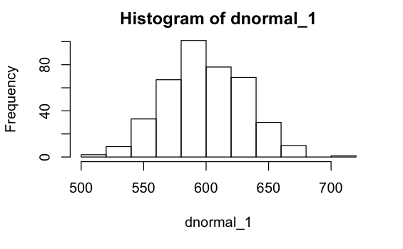

```r
# funcion para simular la distribucion normal
dist_normal_1 <- function(n1, mu1, sigma1) {
  x=rep(0,n1)
  for(i in 1:n1) {
    u1=runif(12, min=0,max=1)
    x[i]=(sum(u1)-6)
  }
  y=mu1+sigma1*x
  return(y)
}

dnormal_1 = dist_normal_1(n, mu, sigma)
hist(dnormal_1)
```

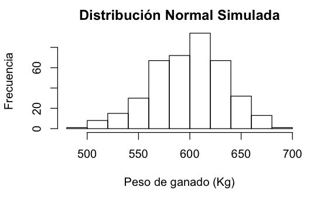

```r
# Segunda forma para simular la distribucion normal
dist_normal_2 <- function(n1, mu1, sigma1) {
  x = rep(0,n1)
  y = rep(0,n1)
  for(i in 1:n1){
    u1 = runif(1, min=0,max=1)
    u2 = runif(1, min=0,max=1)
    r = sqrt(-2*log(u1))
    theta = 2*pi*u2
    x[i] = r*cos(theta)
    y[i] = r*sin(theta)
    X = mu1 + sigma1*x
    Y = mu1 + sigma1*y
  }

  return(data.frame(X,Y))

}

dnormal_2 = dist_normal_2(n, mu, sigma)
hist(dnormal_2$X , xlab="Peso de ganado (Kg)", ylab ="Frecuencia",
     main="Distribución Normal Simulada")
```

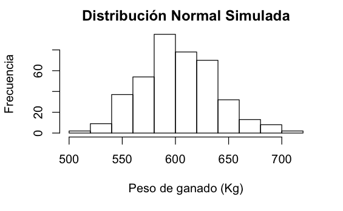

```r
hist(dnormal_2$Y , xlab="Peso de ganado (Kg)", ylab ="Frecuencia",
     main="Distribución Normal Simulada")
```

2.- Presente un contexto para simular 100 datos con las funciones rlogis y rweibull (defina los parámetros según el contexto que elija).

## Distribución Logistica

Ejemplo : Se tiene ganado vacuno con un parametro de posición de 10 y un parametor de scale =2, generar 100 numero pseudo aleatorios con este principio

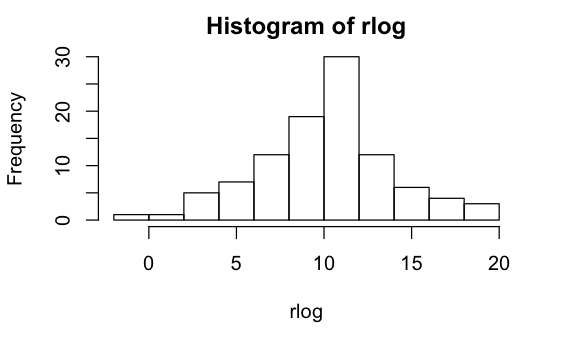

```r
n = 100
rlog = rlogis(n,10,2)
hist(rlog)
```

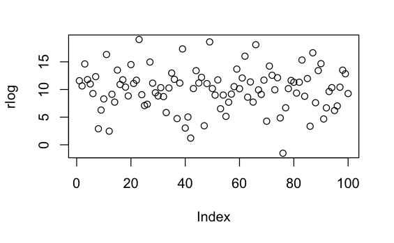

```r
plot(rlog)
```

## Distribución Weibull

Ejemplo : El tiempo de via X en horas de un artefacto en el taller de mecanica tiene una distribución de Weibull con alpha igual a 0,01 y con beta igual a 2 . Se desea simular 100 observaciones

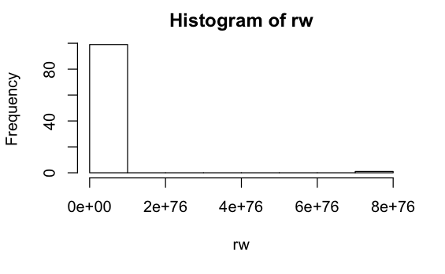

```r
n = 100
rw = rweibull(n, 0.01, 2)
hist(rw)
```

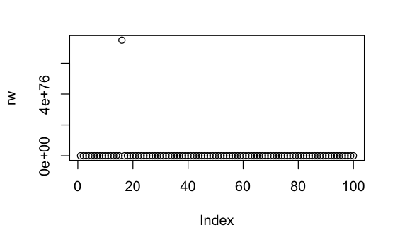

```r
plot(rw)
```

3.- Haga un programa que estime el coeficiente A=3(P75-P25)/4 y su desviación estándar, utilizando muestras con reemplazo de tamaño G, pruebe , utilice los datos iris en la variable Sepal.Length y especie Virginica.

1. Muestre los resultados para G = 50, 100, 2000 , 10000

```r
# funcion de boostrap para calcular A
boostrapA <-function(muestra_base, b) {

  # arreglo de estimador
  estimador=rep(0,b)

  # longitud de la muestra
  len <- length(muestra_base)

  for (i in 1:b) {
    muestra <- sample(muestra_base,len,replace=T)
    estimador[i] <-  3*(quantile(muestra,0.75)-quantile(muestra,0.25))/4
  }

  estboot <- mean(estimador)
  eeboot <- sd(estimador)
  #hist(estimador)
  return( list(estimador=estboot , eestandar=eeboot))
}

library(datasets)
library(dplyr)
data(iris)
names(iris) <- tolower(names(iris))
virginica <- filter(iris, species == "virginica")
head(virginica)
```

|  | sepal.length | sepal.width | petal.length | petal.width | species |
| --- | --- | --- | --- | --- | --- |
| 1 | 6.3 | 3.3 | 6.0 | 2.5 | virginica |
| 2 | 5.8 | 2.7 | 5.1 | 1.9 | virginica |
| 3 | 7.1 | 3.0 | 5.9 | 2.1 | virginica |
| 4 | 6.3 | 2.9 | 5.6 | 1.8 | virginica |
| 5 | 6.5 | 3.0 | 5.8 | 2.2 | virginica |
| 6 | 7.6 | 3.0 | 6.6 | 2.1 | virginica |

G = 50

```r
boostrapA(virginica$sepal.length, 50)
```

```
$estimador
[1] 0.587625

$eestandar
[1] 0.1270338
```

G = 100, ,

```r
boostrapA(virginica$sepal.length, 100)
```

```
$estimador
[1] 0.57075

$eestandar
[1] 0.1306757
```

G = 2000

```r
boostrapA(virginica$sepal.length, 2000)
```

```
$estimador
[1] 0.5698688

$eestandar
[1] 0.1366361
```

G = 10000

```r
boostrapA(virginica$sepal.length, 10000)
```

```
$estimador
[1] 0.572535

$eestandar
[1] 0.1355468
```

2. Modifique el programa para determinar el tamaño de muestras bootstrap necesario considerando 200 repeticiones. Grafique los CV calculados.

```r
#Numero de muestras bootstrap para un valor de B
nmb1=function(datos,B,r){

  ee=rep(0,r)

  for (i in 1:r)
    ee[i]=boostrapA(datos,B)$eestandar

  cv=sd(ee)/abs(mean(ee))  # Coeficiente de variabilidad

  print(cv)

  return(cv)
}
```

```r
nro_rep = 200 # 200
cvs = rep(0,4)
B = c(50,100,2000,10000)

for ( i in 1:4) {
  cvs[i] = nmb1(virginica$sepal.length,B[i],nro_rep)
}
```

```
[1] 0.09238141
[1] 0.06427127
[1] 0.01394033
[1] 0.006414855
```

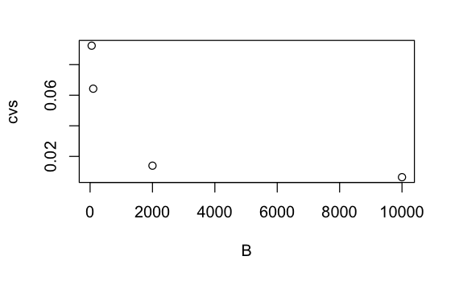

```r
plot(B,cvs)
```